# Week 8 Lab

5/23/2023 and 5/24/2023

Instruction to work on this sheet:

- In each code chunk, you can find some code being taken out purposefully and left with three dots instead
- Your task is to first **uncomment the code line**, then **replace the three dots with the code you would write**

### Today’s topic: clustered data modeling

Refer to the [lecture slides](https://uo-educ-quant.github.io/645/slides/EDUC645_nested_data_Sp23.html#1) and [textbook chapter](https://bookdown.org/roback/bookdown-BeyondMLR/ch-multilevelintro.html) to refresh your content knowledge.

### Data

```r
pacman::p_load(tidyverse, dplyr, lme4, performance, lmerTest, gtsummary, modelsummary)
```

```r
df0 <- read.csv("https://claireconglizhang.github.io/my-slides/EDUC64523S/popular.csv") %>%
  select(pupil, class, extrav, sex, texp, popteach)
head(df0)
```

```
##   pupil class extrav sex texp popteach
## 1     1     1      5   1   24        6
## 2     2     1      7   0   24        5
## 3     3     1      4   1   24        6
## 4     4     1      3   1   24        5
## 5     5     1      5   1   24        6
## 6     6     1      4   0   24        5
```

Data management: - Check if all variables have the right class - pupil, class, sex, should be nominal (factor) rather than continuous (double) - Check if there’s any missing value - Produce a summary stats table

```r
df <- df0 %>%
  mutate_at(c("pupil", "class", "sex"), as.factor)
```

**Table 1. Analytic sample summary statistics**

```r
set_gtsummary_theme(list(
  `tbl_summary-fn:percent_fun` = function(x) sprintf("%.2f", x * 100)
))

df %>%
  select(popteach, extrav, sex, texp) %>%
  tbl_summary(
    statistic = list(all_continuous() ~ "{mean} ({sd})",
                     all_categorical() ~ "{p}%"),
    label = list(popteach ~ "Popularity (rated by teacher)",
                 extrav ~ "Extraversion",
                 sex ~ "Gender",
                 texp ~ "Teacher experience"))
```

| **Characteristic** | **N = 2,000**<sup>1</sup> |
| --- | --- |
| Popularity (rated by teacher) | 5 (1) |
| Extraversion | 5 (1) |
| Gender |  |
| 0 | 49.45% |
| 1 | 50.55% |
| Teacher experience | 14 (7) |

<sup>1</sup> Mean (SD); %

**Q: report the summary stats in a sentence**

### Research question

What is the relationship between popularity rated by teacher and level of extraversion?

Identify your variables: - popteach is outcome variable - extrav is predictor variable - sex and texp are covariates or potential moderators

### Understand data clustering:

The dataset has 2000 students nested in 100 classes.

**Figure 1. Visualization of the bivariate relationship**

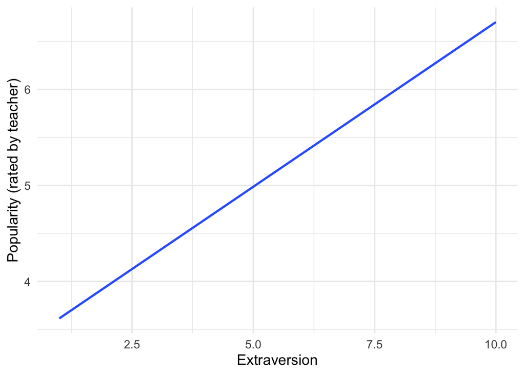

```r
ggplot(df,
       aes(x = extrav, y = popteach)) +
  geom_smooth(method = 'lm', se = F) +
  labs(x = "Extraversion",
       y = "Popularity (rated by teacher)") +
  theme_minimal(base_size = 14)
```

**Figure 2. Visualization of the bivariate relationship within each class (first six classes)**

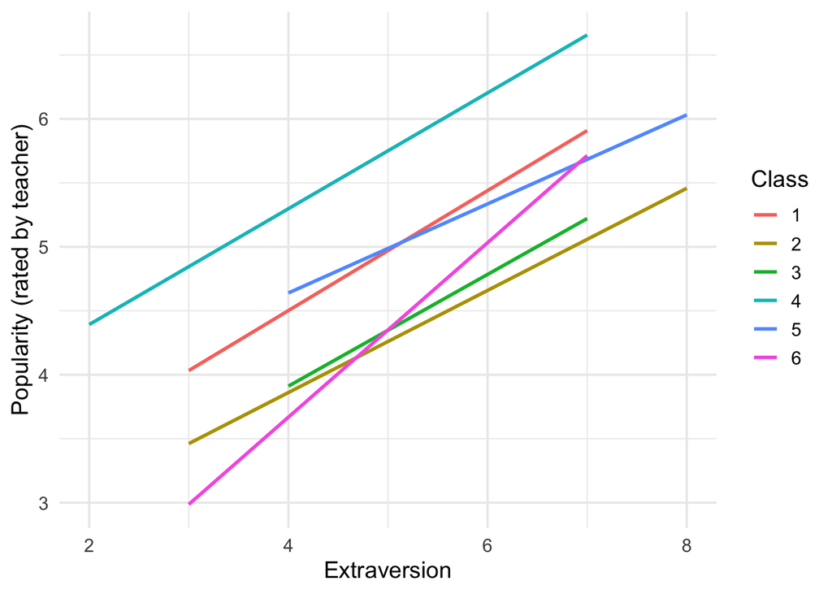

```r
df %>%
  filter(class %in% c("1", "2", "3", "4", "5", "6")) %>%
  ggplot(aes(x = extrav, y = popteach, color = class)) +
  geom_smooth(method = 'lm', se = F) +
  labs(x = "Extraversion",
       y = "Popularity (rated by teacher)",
       color = "Class") +
  theme_minimal(base_size = 14)
```

**Q: compare the two plots in a sentence to illustrate the clustering nature of the data**

### Unconditional model and ICC

Fit an unconditional model.

```r
m0 <- lmer(popteach ~ 1 + (1 | class), df)
coef(summary(m0))
```

```
##             Estimate Std. Error      df  t value     Pr(>|t|)
## (Intercept) 5.061543 0.08628178 98.9777 58.66295 1.066427e-78
```

Calculate the ICC to explain how much variance in ‘popteach’ is attributable to between-class variation

```r
performance::icc(m0)
```

```
## # Intraclass Correlation Coefficient
##
##     Adjusted ICC: 0.343
##   Unadjusted ICC: 0.343
```

**Q: interpret the ICC in a sentence**

### Modeling the relationship (“sex” and “texp” as covariates)

Fixed-effects model:

```r
m1 <- lm(popteach ~ extrav + sex + texp, df)
coef(summary(m1))
```

```
##               Estimate  Std. Error   t value      Pr(>|t|)
## (Intercept) 0.68835369 0.130680076  5.267472  1.532207e-07
## extrav      0.47023247 0.019172979 24.525790 2.512545e-116
## sex1        1.34305366 0.044751276 30.011517 1.221290e-163
## texp        0.08700627 0.003689159 23.584307 1.091160e-108
```

Random-intercepts model:

```r
m2 <- lmer(popteach ~ extrav + sex + texp + (1 | class), df)
coef(summary(m2))
```

```
##               Estimate  Std. Error        df   t value      Pr(>|t|)
## (Intercept) 0.77957004 0.177470302  239.0336  4.392679  1.683226e-05
## extrav      0.46328434 0.017317636 1958.7316 26.752170 1.200312e-134
## sex1        1.22054817 0.039952501 1951.8742 30.549981 7.325099e-168
## texp        0.08732859 0.009023231  102.0973  9.678195  4.164071e-16
```

Random-effects model (allow both intercepts and slopes to vary by “class”):

```r
m3 <- lmer(popteach ~ extrav + sex + texp + (extrav | class), df)
coef(summary(m3))
```

```
##               Estimate  Std. Error         df   t value      Pr(>|t|)
## (Intercept) 0.61905293 0.194333044  188.87841  3.185526  1.690624e-03
## extrav      0.46204614 0.023934304   99.20837 19.304766  2.272465e-35
## sex1        1.21759956 0.039514815 1928.85541 30.813748 6.931081e-170
## texp        0.09655956 0.009027605  104.02965 10.696032  1.869695e-18
```

**Q: interpret each model in a sentence, focus on only the fixed effect, the coeffcient of interest (coefficient on “extrav”).**

### Compare model fitting

Compare the model fitting of random-intercepts model and the random-effects model

```r
performance::compare_performance(m2, m3, metrics = "common") %>%
  print_md()
```

Comparison of Model Performance Indices

| Name | Model | AIC (weights) | BIC (weights) | R2 (cond.) | R2 (marg.) | ICC | RMSE |
| --- | --- | --- | --- | --- | --- | --- | --- |
| m2 | lmerModLmerTest | 5144.5 (<.001) | 5178.2 (2.00e-03) | 0.64 | 0.48 | 0.31 | 0.81 |
| m3 | lmerModLmerTest | 5120.4 (>.999) | 5165.2 (1.00) | 0.67 | 0.49 | 0.35 | 0.78 |

**Q: Compare the two models in a sentence.**

Test whether there is a significant difference in fit between models with and without random slopes:

```r
lmerTest::ranova(m3)
```

```
## ANOVA-like table for random-effects: Single term deletions
##
## Model:
## popteach ~ extrav + sex + texp + (extrav | class)
##                            npar  logLik    AIC    LRT Df Pr(>Chisq)
## <none>                        8 -2563.1 5142.1
## extrav in (extrav | class)    6 -2577.4 5166.9 28.772  2  5.653e-07 ***
## ---
## Signif. codes:  0 '***' 0.001 '**' 0.01 '*' 0.05 '.' 0.1 ' ' 1
```

### Testing interaction effects

“sex” as moderator:

```r
m4 <- lmer(popteach ~ extrav + sex + texp + sex:extrav + (extrav | class), df)

coef(summary(m4))
```

```
##               Estimate  Std. Error        df   t value     Pr(>|t|)
## (Intercept) 0.74444147 0.213296034  244.3486  3.490180 5.725265e-04
## extrav      0.44071628 0.029551353  205.5659 14.913574 1.417616e-34
## sex1        1.00551236 0.174699820 1741.1253  5.755658 1.017789e-08
## texp        0.09536211 0.009030176  103.6861 10.560381 3.896488e-18
## extrav:sex1 0.04105899 0.032986086 1729.1328  1.244737 2.133972e-01
```

“texp” as moderator:

```r
m5 <- lmer(popteach ~ extrav + sex + texp + texp:extrav + (extrav | class), df)
coef(summary(m5))
```

```
##                Estimate  Std. Error        df    t value      Pr(>|t|)
## (Intercept) -1.23239482 0.256683441  238.3752  -4.801224  2.786205e-06
## extrav       0.81183368 0.038784182 1170.0001  20.932082  6.862639e-83
## sex1         1.20606082 0.039003521 1947.6128  30.921844 3.813802e-171
## texp         0.22470523 0.015730492  212.4066  14.284692  6.860838e-33
## extrav:texp -0.02469032 0.002467484 1231.9634 -10.006273  1.025019e-22
```

**Q: are there significant interaction effects?**

### Test assumptions

Let’s select the random-effects model with “extrav” and “texp” interaction.

Residual normality:

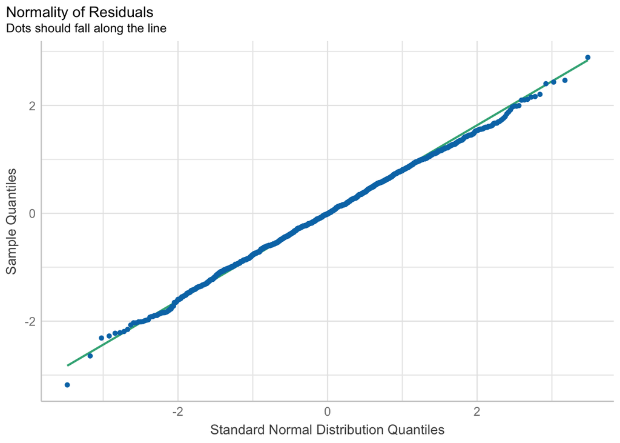

```r
plot(check_normality(m5), type = "qq")
```

Multicollinearity:

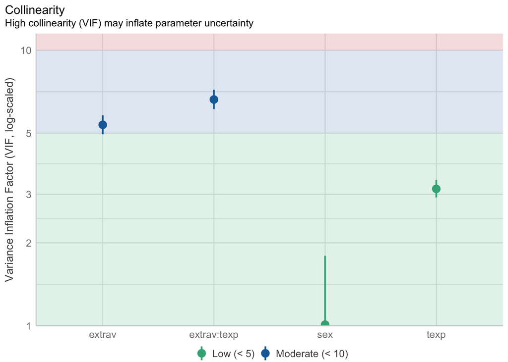

```r
plot(check_collinearity(m5))
```

Influential outliers:

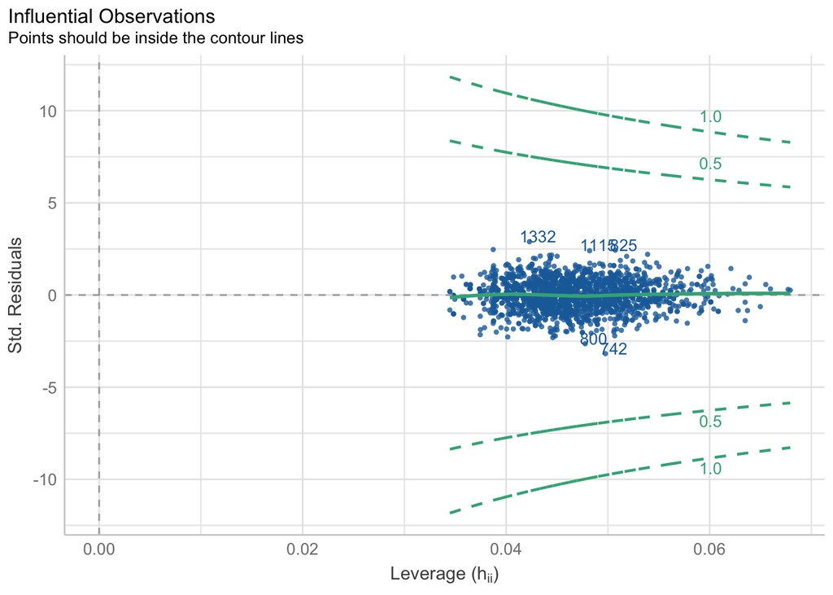

```r
plot(check_outliers(m5))
```

**Q: in a sentence, discuss whether the critical assumptions were violated.**

### Interpreting interaction

```r
library(ggeffects)
predicted <- ggpredict(m5,
                       type = "re",
                       terms = c("extrav", "texp [2, 10, 25]"))
predicted
```

```
## # Predicted values of popteach
##
## # texp = 2
##
## extrav | Predicted |        95% CI
## ----------------------------------
##      1 |     -0.02 | [-1.65, 1.61]
##      2 |      0.74 | [-0.87, 2.36]
##      4 |      2.27 | [ 0.67, 3.87]
##      6 |      3.79 | [ 2.19, 5.39]
##      7 |      4.55 | [ 2.95, 6.15]
##     10 |      6.84 | [ 5.22, 8.47]
##
## # texp = 10
##
## extrav | Predicted |        95% CI
## ----------------------------------
##      1 |      1.58 | [-0.01, 3.17]
##      2 |      2.14 | [ 0.56, 3.73]
##      4 |      3.27 | [ 1.69, 4.86]
##      6 |      4.40 | [ 2.82, 5.99]
##      7 |      4.97 | [ 3.38, 6.55]
##     10 |      6.66 | [ 5.07, 8.26]
##
## # texp = 25
##
## extrav | Predicted |       95% CI
## ---------------------------------
##      1 |      4.58 | [2.97, 6.19]
##      2 |      4.77 | [3.17, 6.38]
##      4 |      5.16 | [3.57, 6.76]
##      6 |      5.55 | [3.96, 7.15]
##      7 |      5.75 | [4.15, 7.35]
##     10 |      6.33 | [4.70, 7.96]
##
## Adjusted for:
## *   sex = 0
## * class = 0 (population-level)
```

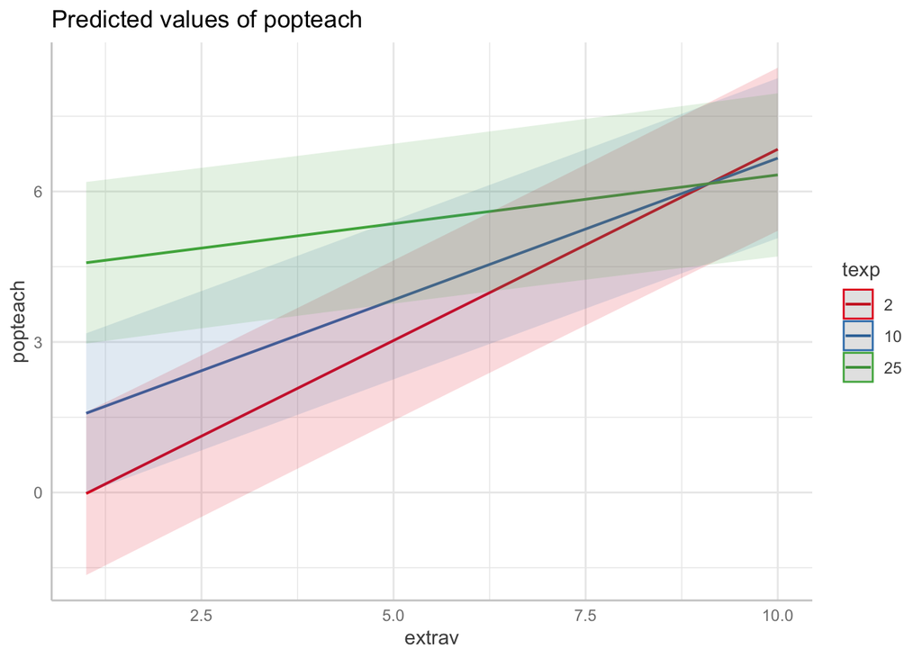

```r
plot(predicted)
```

**Q: In a sentence, interpret how the relationships between teacher rated popularity and extraversion differ by teacher experience.**